# LING 571 - FINAL PROJECT - RADHIKA RAVINDRA

### NLP - Text Classification and Sentiment Analysis on Tweets from Twitter (From the COVID-19 Pandemic Era)

Display the first few rows and columns of datasets used, to better understand the data:

```python
import pandas as pd

corona_nlp_test = pd.read_csv('Corona_NLP_test.csv', encoding='utf-8')
corona_nlp_train = pd.read_csv('Corona_NLP_train.csv', encoding='iso-8859-1')

corona_nlp_test.head(), corona_nlp_train.head()
```

```
(   UserName  ScreenName             Location     TweetAt  \
 0         1       44953                  NYC  02-03-2020
 1         2       44954          Seattle, WA  02-03-2020
 2         3       44955                  NaN  02-03-2020
 3         4       44956          Chicagoland  02-03-2020
 4         5       44957  Melbourne, Victoria  03-03-2020

                                        OriginalTweet           Sentiment
 0  TRENDING: New Yorkers encounter empty supermar...  Extremely Negative
 1  When I couldn't find hand sanitizer at Fred Me...            Positive
 2  Find out how you can protect yourself and love...  Extremely Positive
 3  #Panic buying hits #NewYork City as anxious sh...            Negative
 4  #toiletpaper #dunnypaper #coronavirus #coronav...             Neutral  ,
    UserName  ScreenName   Location     TweetAt  \
 0      3799       48751     London  16-03-2020
 1      3800       48752         UK  16-03-2020
 2      3801       48753  Vagabonds  16-03-2020
 3      3802       48754        NaN  16-03-2020
 4      3803       48755        NaN  16-03-2020

                                        OriginalTweet           Sentiment
 0  @MeNyrbie @Phil_Gahan @Chrisitv https://t.co/i...             Neutral
 1  advice Talk to your neighbours family to excha...            Positive
 2  Coronavirus Australia: Woolworths to give elde...            Positive
 3  My food stock is not the only one which is emp...            Positive
 4  Me, ready to go at supermarket during the #COV...  Extremely Negative  )
```

```python
import nltk
from nltk.corpus import stopwords
from nltk.tokenize import word_tokenize
from nltk.stem import WordNetLemmatizer

nltk.download('punkt')
nltk.download('stopwords')
nltk.download('wordnet')

# Tokenization

def tokenize_text(text):
    tokens = word_tokenize(text)
    return tokens

corona_nlp_train['TokenizedTweet'] = corona_nlp_train['OriginalTweet'].apply(tokenize_text)
corona_nlp_test['TokenizedTweet'] = corona_nlp_test['OriginalTweet'].apply(tokenize_text)

corona_nlp_train.head(), corona_nlp_test.head()
```

```
(   UserName  ScreenName   Location     TweetAt  \
 0      3799       48751     London  16-03-2020
 1      3800       48752         UK  16-03-2020
 2      3801       48753  Vagabonds  16-03-2020
 3      3802       48754        NaN  16-03-2020
 4      3803       48755        NaN  16-03-2020

                                        OriginalTweet           Sentiment  \
 0  @MeNyrbie @Phil_Gahan @Chrisitv https://t.co/i...             Neutral
 1  advice Talk to your neighbours family to excha...            Positive
 2  Coronavirus Australia: Woolworths to give elde...            Positive
 3  My food stock is not the only one which is emp...            Positive
 4  Me, ready to go at supermarket during the #COV...  Extremely Negative

                                       TokenizedTweet
```

[output cut: 25 more lines]

```python
# Remove stopwords and perform lemmatization

lemmatizer = WordNetLemmatizer()
stop_words = set(stopwords.words('english'))

# Function to remove stopwords and perform lemmatization

def clean_tokens(tokens):
    return [lemmatizer.lemmatize(word.lower()) for word in tokens if word.isalpha() and word.lower() not in stop_words]

corona_nlp_train['CleanedTweet'] = corona_nlp_train['TokenizedTweet'].progress_apply(clean_tokens)
corona_nlp_test['CleanedTweet'] = corona_nlp_test['TokenizedTweet'].progress_apply(clean_tokens)

# Drop the 'TokenizedTweet' column as it's no longer needed

corona_nlp_train.drop(columns=['TokenizedTweet'], inplace=True)
corona_nlp_test.drop(columns=['TokenizedTweet'], inplace=True)

# Ensure both dataframes have the same columns

columns_to_keep = ['UserName', 'ScreenName', 'Location', 'TweetAt', 'OriginalTweet', 'Sentiment', 'CleanedTweet']
corona_nlp_train = corona_nlp_train[columns_to_keep]
corona_nlp_test = corona_nlp_test[columns_to_keep]

# Display the head of both dataframes to confirm

corona_nlp_train.head(), corona_nlp_test.head()
```

```
(   UserName  ScreenName   Location     TweetAt  \
 0      3799       48751     London  16-03-2020
 1      3800       48752         UK  16-03-2020
 2      3801       48753  Vagabonds  16-03-2020
 3      3802       48754        NaN  16-03-2020
 4      3803       48755        NaN  16-03-2020

                                        OriginalTweet           Sentiment  \
 0  @MeNyrbie @Phil_Gahan @Chrisitv https://t.co/i...             Neutral
 1  advice Talk to your neighbours family to excha...            Positive
 2  Coronavirus Australia: Woolworths to give elde...            Positive
 3  My food stock is not the only one which is emp...            Positive
 4  Me, ready to go at supermarket during the #COV...  Extremely Negative

                                         CleanedTweet
```

[output cut: 25 more lines]

```python
from tqdm import tqdm

tqdm.pandas()

# Redefine the clean_tokens function with progress_apply

def clean_tokens(tokens):
    return [lemmatizer.lemmatize(word.lower()) for word in tokens if word.isalpha() and word.lower() not in stop_words]

corona_nlp_train['TokenizedTweet'] = corona_nlp_train['OriginalTweet'].apply(tokenize_text)
corona_nlp_test['TokenizedTweet'] = corona_nlp_test['OriginalTweet'].apply(tokenize_text)

corona_nlp_train['CleanedTweet'] = corona_nlp_train['TokenizedTweet'].progress_apply(clean_tokens)
corona_nlp_test['CleanedTweet'] = corona_nlp_test['TokenizedTweet'].progress_apply(clean_tokens)

corona_nlp_train.drop(columns=['TokenizedTweet'], inplace=True)
corona_nlp_test.drop(columns=['TokenizedTweet'], inplace=True)

columns_to_keep = ['UserName', 'ScreenName', 'Location', 'TweetAt', 'OriginalTweet', 'Sentiment', 'CleanedTweet']
corona_nlp_train = corona_nlp_train[columns_to_keep]
corona_nlp_test = corona_nlp_test[columns_to_keep]
corona_nlp_train.head(), corona_nlp_test.head()
```

```
(   UserName  ScreenName   Location     TweetAt  \
 0      3799       48751     London  16-03-2020
 1      3800       48752         UK  16-03-2020
 2      3801       48753  Vagabonds  16-03-2020
 3      3802       48754        NaN  16-03-2020
 4      3803       48755        NaN  16-03-2020

                                        OriginalTweet           Sentiment  \
 0  @MeNyrbie @Phil_Gahan @Chrisitv https://t.co/i...             Neutral
 1  advice Talk to your neighbours family to excha...            Positive
 2  Coronavirus Australia: Woolworths to give elde...            Positive
 3  My food stock is not the only one which is emp...            Positive
 4  Me, ready to go at supermarket during the #COV...  Extremely Negative

                                         CleanedTweet
```

[output cut: 25 more lines]

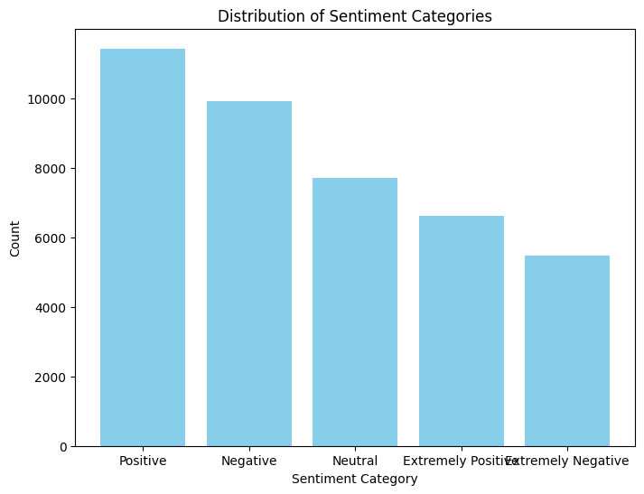

```python
import matplotlib.pyplot as plt

# Visualize the distribution of sentiment categories
sentiment_counts = corona_nlp_train['Sentiment'].value_counts()

plt.figure(figsize=(8, 6))
plt.bar(sentiment_counts.index, sentiment_counts.values, color='skyblue')
plt.title('Distribution of Sentiment Categories')
plt.xlabel('Sentiment Category')
plt.ylabel('Count')
plt.show()
```

The bar chart above displays the distribution of sentiment categories in the training dataset. Each sentiment category is represented on the x-axis, while the count of tweets associated with each sentiment is shown on the y-axis. This visualization provides a clear representation of the balance or imbalance between different sentiment classes, allowing us to observe which sentiments are more prevalent and which are less common in the dataset.

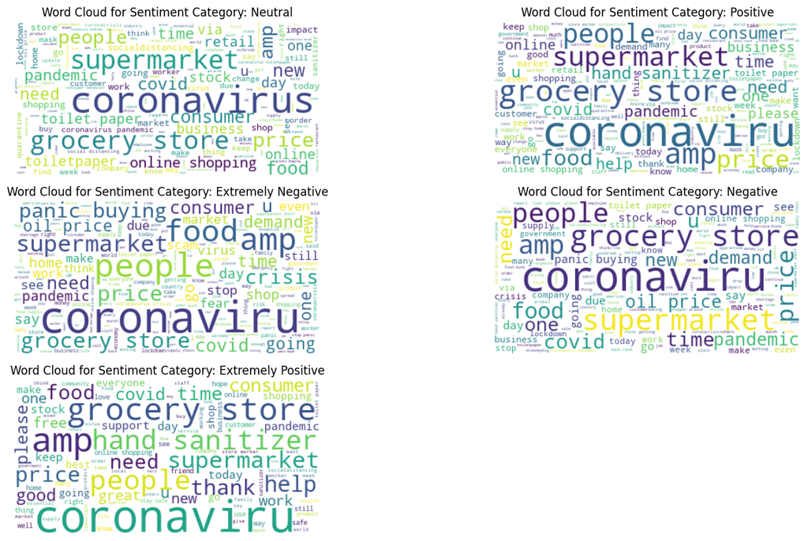

```python
from wordcloud import WordCloud
import matplotlib.pyplot as plt

# Generate word clouds for each sentiment category
sentiment_categories = corona_nlp_train['Sentiment'].unique()

# Set up subplots for word clouds
num_categories = len(sentiment_categories)
rows = int(num_categories / 2) + (num_categories % 2)
cols = 2

fig, axes = plt.subplots(rows, cols, figsize=(15, 8))

for i, category in enumerate(sentiment_categories):
    text = ' '.join(corona_nlp_train[corona_nlp_train['Sentiment'] == category]['CleanedTweet'].apply(lambda x: ' '.join(x)).values)
    wordcloud = WordCloud(width=400, height=200, background_color='white').generate(text)
    ax = axes[int(i / 2), i % 2] if num_categories > 1 else axes
    ax.imshow(wordcloud, interpolation='bilinear')
    ax.set_title('Word Cloud for Sentiment Category: ' + category)
    ax.axis('off')

# Remove empty subplots if needed
if num_categories % 2 != 0:
    fig.delaxes(axes[rows - 1, 1])

plt.tight_layout()
plt.show()
```

The word clouds above represent the most frequent words found in tweets for each sentiment category within the training dataset. Each word cloud corresponds to a different sentiment, providing a visual representation of the words that are most characteristic of each sentiment.

Visualize with respect to time, how different sentiments have evolved during the peak time of pandemic - march to april 2020:

[output not shown]

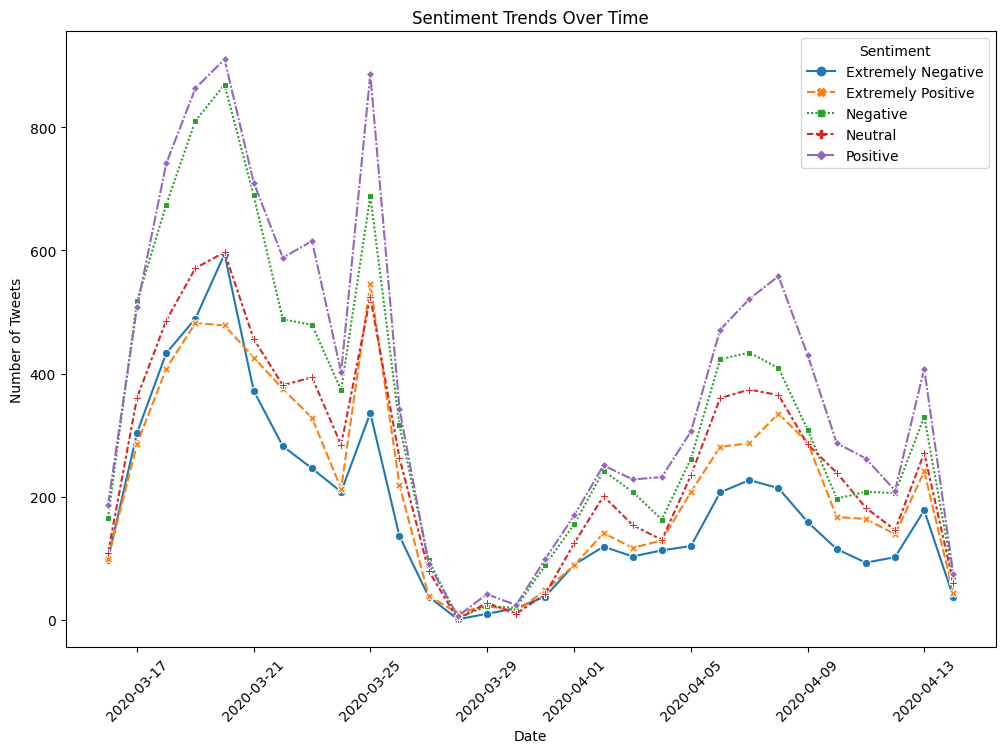

```python
import seaborn as sns
import pandas as pd

# Convert the timestamp to datetime
corona_nlp_train['TweetAt'] = pd.to_datetime(corona_nlp_train['TweetAt'])

# Group by date and sentiment to get the count of tweets for each sentiment on each date
sentiment_trends = corona_nlp_train.groupby([corona_nlp_train['TweetAt'].dt.date, 'Sentiment']).size().unstack()

# Plot the sentiment trends over time
plt.figure(figsize=(12, 8))
sns.lineplot(data=sentiment_trends, markers=True)
plt.title('Sentiment Trends Over Time')
plt.xlabel('Date')
plt.ylabel('Number of Tweets')
plt.xticks(rotation=45)
plt.show()
```

Next, I will be performing Logistic Regression on the data - to build a model that can predict the sentiment of tweets based on their content. The logistic regression model uses the cleaned tweet data to learn the relationship between the words in the tweets and the sentiment labels. By training this model, I aim to accurately classify tweets into different sentiment categories, which can provide valuable insights into public sentiment during the COVID-19 pandemic.

```python
from sklearn.feature_extraction.text import TfidfVectorizer
from sklearn.model_selection import train_test_split
from sklearn.linear_model import LogisticRegression
from sklearn.metrics import accuracy_score, classification_report


# Initialize the TfidfVectorizer
vectorizer = TfidfVectorizer(max_features=1000)

# Fit and transform the training data
X_train = vectorizer.fit_transform(train_tweets)

# Transform the test data
X_test = vectorizer.transform(test_tweets)

# Define the target variable
y_train = corona_nlp_train['Sentiment']
y_test = corona_nlp_test['Sentiment']

# Initialize the Logistic Regression model
model = LogisticRegression(max_iter=1000)

# Fit the model on the training data
model.fit(X_train, y_train)

# Predict the sentiment on the test data
y_pred = model.predict(X_test)

# Calculate the accuracy
accuracy = accuracy_score(y_test, y_pred)

# Generate the classification report
report = classification_report(y_test, y_pred)

# Displaying the results
print(f"Accuracy: {accuracy:.2f}\n")
print("Classification Report:")
print(report)
```

```
Accuracy: 0.52

Classification Report:
                    precision    recall  f1-score   support

Extremely Negative       0.54      0.42      0.47       592
Extremely Positive       0.66      0.52      0.58       599
          Negative       0.48      0.43      0.46      1041
           Neutral       0.54      0.67      0.60       619
          Positive       0.47      0.57      0.51       947

          accuracy                           0.52      3798
         macro avg       0.54      0.52      0.52      3798
      weighted avg       0.52      0.52      0.52      3798
```